# Mutation Timecourse Plotting

```r
library(Biostrings)
library(tidyverse)
data_filepath = "/Volumes/Nick Minor External HD 1/E484T/"
setwd(data_filepath)
```

# Plotting Mutations through Time

## Data Preparation

In order to run the code below, you need to have gone through the following steps:

1. Downloaded the Wuhan SARS-CoV-2 sequence. Mine is called gisaid_hcov-19_2021_09_09_16.fasta
2. Imported the “all time points” fasta and the Wuhan sequence into Geneious.
3. Aligned all samples to the Wuhan reference, both with all in one and with each sample individually. In the end, this should give you *7* alignments.
4. Annonated SNPs/Variation for each of these alignments. *Make sure you click “NO” each time it asks if you want to apply these annotations to the original sequence.*
5. Export VCFs with no filtering into your data folder.
6. Insert your data folder filepath into the “data_filepath” line above, and you’re good to go!

Next, we’ll read in and re-format the patient’s sequence data:

```r
patient_fasta <- readDNAStringSet("/Volumes/Nick Minor External HD 1/E484T/PT0001_alltimepoints_20210908.fasta")
seq_names = names(patient_fasta)
sequence = paste(patient_fasta)
fasta_df <- data.frame(seq_names, sequence)
fasta_df$seq_names <- str_replace_all(fasta_df$seq_names, fixed(" | "), ",")
fasta_df <- separate(data = fasta_df, col = 1,
         into = c("Sample_ID", "Date"),
         sep = ",")
fasta_df$Date <- as.Date(fasta_df$Date, "%Y %b %d")
fasta_df$day_of_infection <- c(113,124,131,159,198,297)
```

Now, having completed these steps, we need to accomplish two goals with our mutation data: We need a column in our data containing all recorded dates for a given mutation, and another column that contains only the dates when each mutation was first detected. We’ll start with them former:

```r
crude_vcf = read.delim("/Volumes/Nick Minor External HD 1/E484T/alltimepoints_variants.vcf", skip = 13)

# creating a column with all dates of detection for each mutation
for (i in 1:nrow(crude_vcf)){
  info <- crude_vcf[i, "INFO"]
  info_split <- unlist(strsplit(info, split = ";"))
  crude_vcf[i, "DATES_DETECTED"] <- info_split[grep("^VARSEQ", info_split)]
}
crude_vcf$DATES_DETECTED <- str_replace_all(crude_vcf$DATES_DETECTED, "VARSEQ=", "")

# parsing out and sorting the dates
for (i in 1:nrow(crude_vcf)){
  varseq <- crude_vcf[i,"DATES_DETECTED"]
  samples <- unlist(strsplit(varseq, split = ","))
  samples_ordered <- samples[match(fasta_df$Sample_ID, samples)]
  samples_ordered <- as.character(na.omit(samples_ordered))
  dates_ordered <- samples_ordered
  ref <- fasta_df[match(dates_ordered, fasta_df$Sample_ID),1:2]
  for (j in 1:length(dates_ordered)){
    dates_ordered[j] <- as.character(ref[j, "Date"])
    }
  if (length(dates_ordered)>1){
    dates_ordered <- paste0(dates_ordered, collapse = ",")
  }
  crude_vcf[i,"DATES_DETECTED"] <- as.character(dates_ordered)
}

# creating a column with all *days* (note dates) of detection, from the patient's first day of infection
for (i in 1:nrow(crude_vcf)){
  info <- crude_vcf[i, "INFO"]
  info_split <- unlist(strsplit(info, split = ";"))
  crude_vcf[i, "DAYS_DETECTED"] <- info_split[grep("^VARSEQ", info_split)]
}
crude_vcf$DAYS_DETECTED <- str_replace_all(crude_vcf$DAYS_DETECTED, "VARSEQ=", "")

# parsing out and sorting the days
for (i in 1:nrow(crude_vcf)){
  varseq <- crude_vcf[i,"DAYS_DETECTED"]
  samples <- unlist(strsplit(varseq, split = ","))
  samples_ordered <- samples[match(fasta_df$Sample_ID, samples)]
  samples_ordered <- as.character(na.omit(samples_ordered))
  days_ordered <- samples_ordered
  ref <- fasta_df[match(days_ordered, fasta_df$Sample_ID),c(1,4)]
  for (j in 1:length(days_ordered)){
    days_ordered[j] <- as.character(ref[j, "day_of_infection"])
  }
  if (length(days_ordered)>1){
    days_ordered <- paste0(days_ordered, collapse = ",")
  }
  crude_vcf[i,"DAYS_DETECTED"] <- as.character(days_ordered)
}
```

The next step–creating columns of earliest dates and days–will be easier now that we’ve already done most of the work. Note also that this step is only less code-intensive because we previously put the dates in chronological order. This being the case, we can simply tell R “take the first item in the list here, copy it, and put the copy over in this other column.” Using a loop, we will repeat this operation for every row.

```r
crude_vcf$EARLIEST_DATE <- NA
crude_vcf$EARLIEST_DAY <- NA

for (i in 1:nrow(crude_vcf)){
  sub <- crude_vcf$DATES_DETECTED[i]
  crude_vcf$EARLIEST_DATE[i] <- unlist(strsplit(sub, split = ","))[1]
}
crude_vcf$EARLIEST_DATE <- as.Date(crude_vcf$EARLIEST_DATE, format = "%Y-%m-%d")
for (i in 1:nrow(crude_vcf)){
  sub <- crude_vcf$DAYS_DETECTED[i]
  crude_vcf$EARLIEST_DAY[i] <- unlist(strsplit(sub, split = ","))[1]
}
crude_vcf$EARLIEST_DAY <- as.numeric(crude_vcf$EARLIEST_DAY)
```

Only a littler further to go now. We would be ready for plotting now, except that you can’t plot a list of comma-separated dates at once. This means it won’t be as simple as plotting the contents of column “DATES_DETECTED” in the Y-axis and the genome position in the X-axis. Instead, we need to “unspool” or separate each date into their own objects within a vector.

To do this, while also retaining information about genome position, we’re going to use a list. In R, lists are like hierarchical vectors (like vectors within vectors, and so on). Here, we making a list where the first level down is the genome positions for each mutation. Then, within each position is a vector of dates when the mutation at that position were detected.

When we plot these lists, we will essentially transform subsets of this list back into vectors of dates to plot, with the genome position repeating for the number of dates.

Okay, explanation aside, let’s do the damn thing:

```r
# first for dates
mut_list1 <- vector("list", length = nrow(crude_vcf))
names(mut_list1) <- as.numeric(crude_vcf$POS)
for (i in 1:nrow(crude_vcf)){
  sub <- crude_vcf[i, "DATES_DETECTED"]
  sub_split <- unlist(strsplit(sub, split = ","))
  dates <- as.Date(sub_split, format = "%Y-%m-%d")
  mut_list1[[i]] <- dates
}

# second for days
mut_list2 <- vector("list", length = nrow(crude_vcf))
names(mut_list2) <- as.numeric(crude_vcf$POS)
for (i in 1:nrow(crude_vcf)){
  sub <- crude_vcf[i, "DAYS_DETECTED"]
  sub_split <- unlist(strsplit(sub, split = ","))
  days <- as.numeric(sub_split)
  mut_list2[[i]] <- days
}
```

## Plotting

Finally! We’re ready to plot. We’ll start by plotting all days, and then we’ll plot the earliest days.

To plot the data in a visually pleasing and informative way, we’re going to prepare the plot axes first and then add data. To do so, we’ll start by making a table of SARS-CoV-2 gene information, which I copied from Nextstrain.org

```r
SARS_genes <- data.frame("name" = c("ORF1a", "ORF1b", "S", NA, NA, NA, NA, NA, NA, NA, "N"),
                         "start" = c(266, 13469, 21563, 25393, 26245, 26523, 27202, 27394, 27894, 28284, 28578),
                         "stop" = c(13468, 21555, 25384, 26220, 26472, 27191, 27387, 27759, 28259, 28577, 29533),
                         "col" = c("lightgreen", "orange", "lightblue", "lightgreen", "gold", "lightblue", "orange",
                                   "lightgreen", "lightblue", "gold", "orange"),
                         "left_out_names" = c(NA, NA, NA, "ORF3a", "E", "M", "ORF6", "ORF7a", "ORF8", "ORF9b", NA))
```

The table specifies the names of the genes, the start and stop positions, as well as the colors I will graph them in. Some of the genes are too small to fit a whole gene name in them in the plot; I’ve moved these gene names into the column “left_out_names” so R ignores them later.

Now, we’ll put it together to see the template we’ll fill the data into

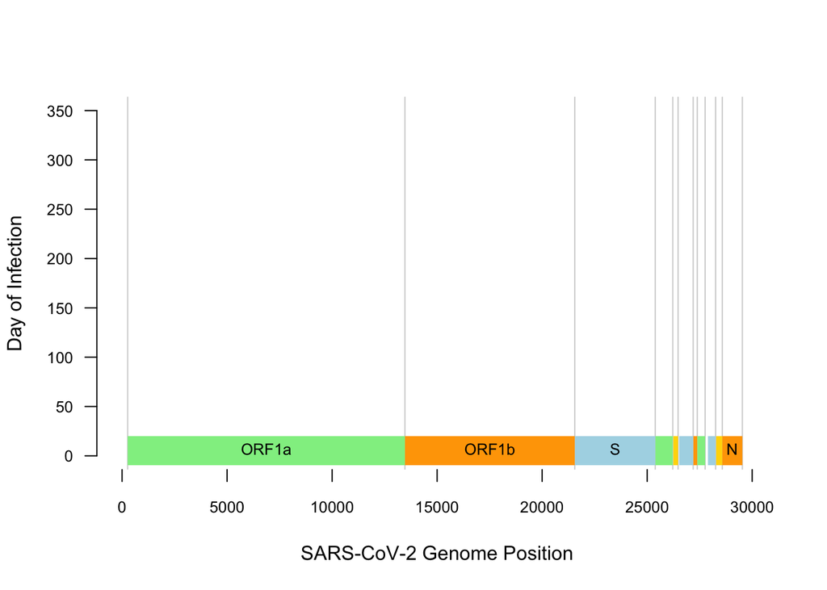

```r
{plot(1,1, xlim = c(0,30000), ylim=c(0, 350), type = "n",
     xlab = "SARS-CoV-2 Genome Position", ylab = "Day of Infection",
     frame.plot = F, cex.axis = 0.8, las = 1, xaxt = "n")
axis(side = 1, at = c(0,5000,10000,15000,20000,25000,30000), cex.axis = 0.8,
     col = "white", col.ticks = "black")
abline(v=SARS_genes$stop, col = "lightgrey")
abline(v=SARS_genes$start[1], col = "lightgrey")

for (i in 1:nrow(SARS_genes)){
  polygon(x = c(SARS_genes[i,"start"], SARS_genes[i,"start"],
                SARS_genes[i,"stop"], SARS_genes[i,"stop"]),  # coordinates of gene
          y = c(-9.5, 20, 20, -9.5),    # Y-Coordinates of polygon
          col = SARS_genes[i,"col"], border = F)
  text(x = SARS_genes[i,"start"] + (SARS_genes[i,"stop"]-SARS_genes[i,"start"])/2,
       y = (20--9.5)/4, labels = SARS_genes[i, "name"], col = "black", cex = 0.8)
}
}
```

Next, we’ll add grayed-out all-date points using our lists from above:

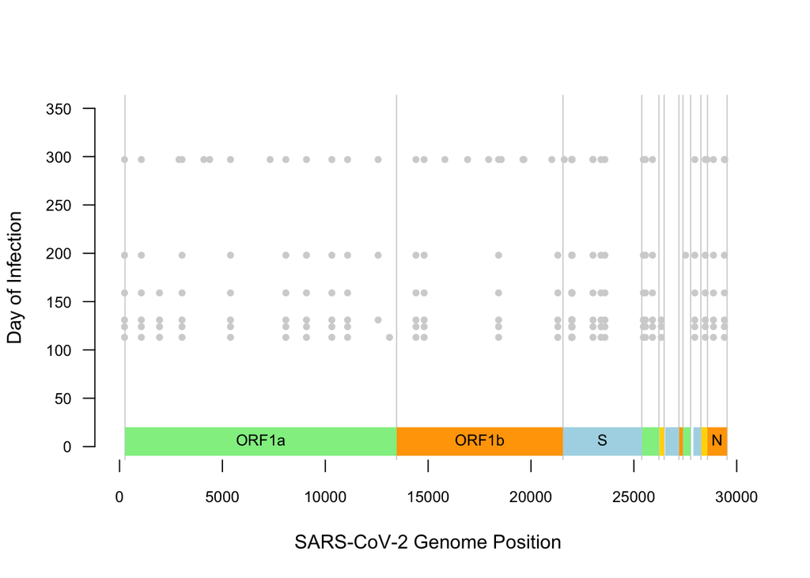

```r
{plot(1,1, xlim = c(0,30000), ylim=c(0, 350), type = "n",
     xlab = "SARS-CoV-2 Genome Position", ylab = "Day of Infection",
     frame.plot = F, cex.axis = 0.8, las = 1, xaxt = "n")
axis(side = 1, at = c(0,5000,10000,15000,20000,25000,30000), cex.axis = 0.8,
     col = "white", col.ticks = "black")
abline(v=SARS_genes$stop, col = "lightgrey")
abline(v=SARS_genes$start[1], col = "lightgrey")

for (i in 1:nrow(SARS_genes)){
  polygon(x = c(SARS_genes[i,"start"], SARS_genes[i,"start"],
                SARS_genes[i,"stop"], SARS_genes[i,"stop"]),  # coordinates of gene
          y = c(-9.5, 20, 20, -9.5),    # Y-Coordinates of polygon
          col = SARS_genes[i,"col"], border = F)
  text(x = SARS_genes[i,"start"] + (SARS_genes[i,"stop"]-SARS_genes[i,"start"])/2,
       y = (20--9.5)/4, labels = SARS_genes[i, "name"], col = "black", cex = 0.8)
}

for (i in 1:length(mut_list2)){
  plotting_data <- data.frame("Date" = mut_list2[[i]],
                              "Coordinate" = rep(as.numeric(names(mut_list2)[i]), times = length(mut_list2[[i]])))
  points(x = plotting_data$Coordinate, plotting_data$Date, type = "p", pch = 20, col = "lightgrey")
}
}
```

And finally, we’ll put it all together:

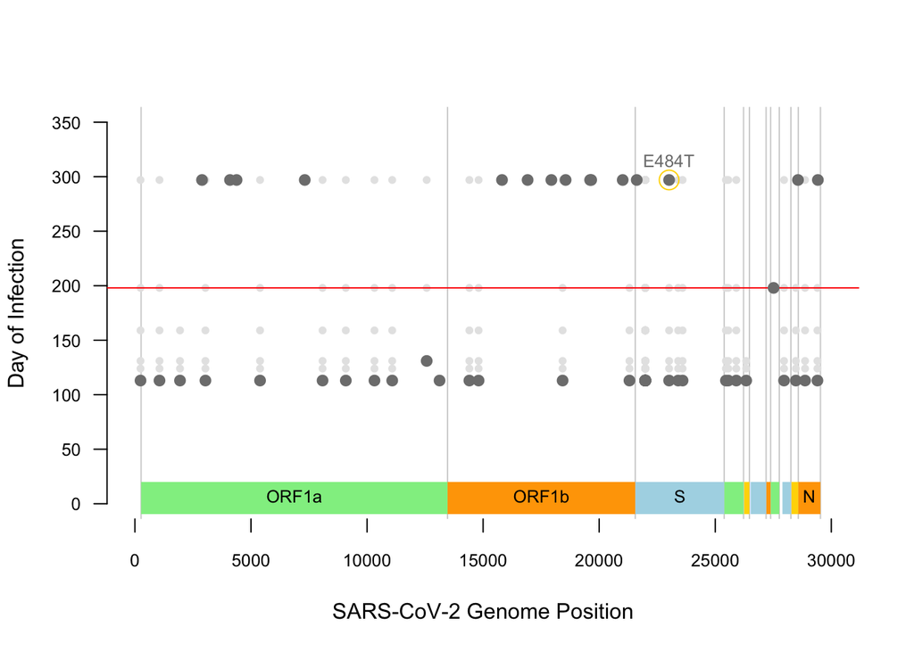

```r
{plot(1,1, xlim = c(0,30000), ylim=c(0, 350), type = "n",
     xlab = "SARS-CoV-2 Genome Position", ylab = "Day of Infection",
     frame.plot = F, cex.axis = 0.8, las = 1, xaxt = "n")
axis(side = 1, at = c(0,5000,10000,15000,20000,25000,30000), cex.axis = 0.8,
     col = "white", col.ticks = "black")
abline(v=SARS_genes$stop, col = "lightgrey")
abline(v=SARS_genes$start[1], col = "lightgrey")

for (i in 1:nrow(SARS_genes)){
  polygon(x = c(SARS_genes[i,"start"], SARS_genes[i,"start"],
                SARS_genes[i,"stop"], SARS_genes[i,"stop"]),  # coordinates of gene
          y = c(-9.5, 20, 20, -9.5),    # Y-Coordinates of polygon
          col = SARS_genes[i,"col"], border = F)
  text(x = SARS_genes[i,"start"] + (SARS_genes[i,"stop"]-SARS_genes[i,"start"])/2,
       y = (20--9.5)/4, labels = SARS_genes[i, "name"], col = "black", cex = 0.8)
}

for (i in 1:length(mut_list2)){
  plotting_data <- data.frame("Date" = mut_list2[[i]],
                              "Coordinate" = rep(as.numeric(names(mut_list2)[i]), times = length(mut_list2[[i]])))
  points(x = plotting_data$Coordinate, plotting_data$Date, type = "p", pch = 20, col = "#e5e5e5")
}

abline(h=198, col = "red")
# text(x = 29500, y = 210, labels = "Bamlanivumab administered", cex = 0.8, las = 3)
points(crude_vcf$POS, crude_vcf$EARLIEST_DAY, pch = 16, col = "#7e7e7e", cex = 1.2)
points(23012, crude_vcf[crude_vcf$POS==23012,"EARLIEST_DAY"],
       pch = 1, cex = 2, col = "gold")
text(23000, 315, labels = "E484T", col = "#7e7e7e", cex = 0.8)
}
```

This is pretty close to a finished figure. Except…one thing that could be useful is only plotting *novel* mutations in dark gray, leaving all the fixed mutations that appear in every sequencing event as light gray. To do so, we just need to add a simple loop that will produce a vector of TRUE’s and FALSE’s. These T/F’s will be based on whether a mutation is fixed (T; present in all 6 sequencing events) or novel (F; present in fewer than 6 sequencing events). We will then use this boolean vector to determine which mutations will then get plotted in dark gray.

While we’re at it, let’s add a legend too.

Here’s the code for that:

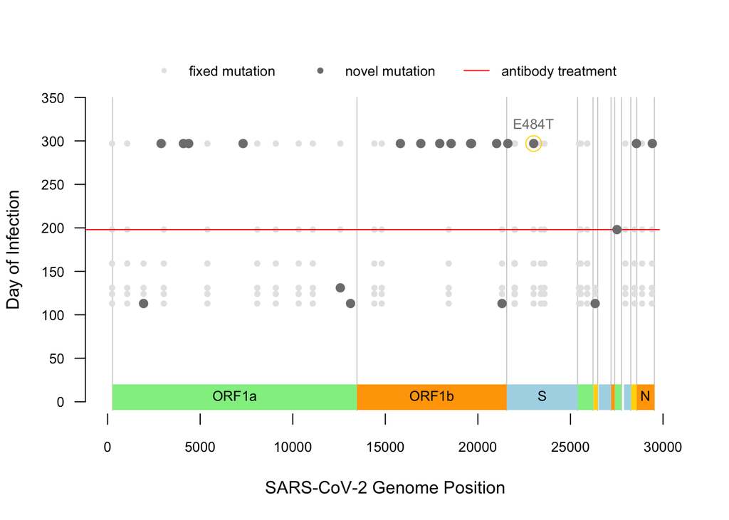

```r
{plot(1,1, xlim = c(0,30000), ylim=c(0, 350), type = "n",
     xlab = "SARS-CoV-2 Genome Position", ylab = "Day of Infection",
     frame.plot = F, cex.axis = 0.8, las = 1, xaxt = "n")
axis(side = 1, at = c(0,5000,10000,15000,20000,25000,30000), cex.axis = 0.8,
     col = "white", col.ticks = "black")
segments(x0=SARS_genes$stop,
         y0 = rep(-10, times = length(SARS_genes$stop)),
         y1 = rep(350, times = length(SARS_genes$stop)),
         col = "lightgrey")
segments(x0 = SARS_genes$start[1], y0 = -10, y1 = 350, col = "lightgrey")

for (i in 1:nrow(SARS_genes)){
  polygon(x = c(SARS_genes[i,"start"], SARS_genes[i,"start"],
                SARS_genes[i,"stop"], SARS_genes[i,"stop"]),  # coordinates of gene
          y = c(-9.5, 20, 20, -9.5),    # Y-Coordinates of polygon
          col = SARS_genes[i,"col"], border = F)
  text(x = SARS_genes[i,"start"] + (SARS_genes[i,"stop"]-SARS_genes[i,"start"])/2,
       y = (20--9.5)/4, labels = SARS_genes[i, "name"], col = "black", cex = 0.8)
}

for (i in 1:length(mut_list2)){
  plotting_data <- data.frame("Date" = mut_list2[[i]],
                              "Coordinate" = rep(as.numeric(names(mut_list2)[i]), times = length(mut_list2[[i]])))
  points(x = plotting_data$Coordinate, plotting_data$Date, type = "p", pch = 20, col = "#e5e5e5")
}

fixed <- rep(NA, times = length(mut_list2))
for (i in 1:length(fixed)){
  fixed[i] <- length(mut_list2[[i]])==6
}

segments(x0 = -1200, x1 = 29800, y0=198, col = "red")
# text(x = 29500, y = 210, labels = "Bamlanivumab administered", cex = 0.8, las = 3)
points(crude_vcf[!fixed, "POS"], crude_vcf[!fixed, "EARLIEST_DAY"], pch = 16, col = "#7e7e7e", cex = 1.2)
points(23012, crude_vcf[crude_vcf$POS==23012,"EARLIEST_DAY"],
       pch = 1, cex = 2, col = "gold")
text(23000, 320, labels = "E484T", col = "#7e7e7e", cex = 0.8)

legend(15000,400, legend=c("fixed mutation", "novel mutation", "antibody treatment"),
       pch = c(20, 16, NA), lty = c(NA, NA, 1),
       col = c("#e5e5e5", "#7e7e7e", "red"),
       bty = "o", cex = 0.8, box.col = "white", ncol = 3, xpd = T, xjust = 0.5)
}
```

And, just because it’s easy to do, let’s switch the axes so that time is in its natural place: increasing along the X-axis:

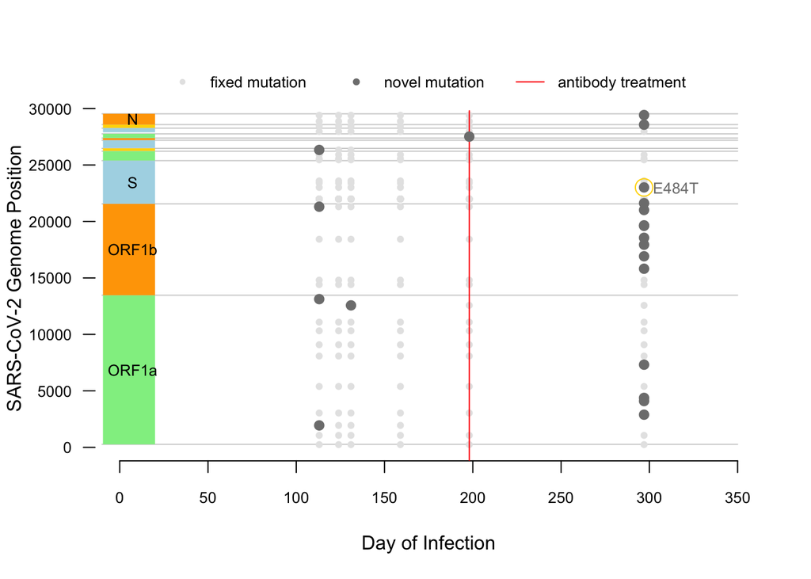

```r
{plot(1,1, ylim = c(0,30000), xlim=c(0, 350), type = "n",
     ylab = "SARS-CoV-2 Genome Position", xlab = "Day of Infection",
     frame.plot = F, cex.axis = 0.8, yaxt = "n")
axis(side = 2, at = c(0,5000,10000,15000,20000,25000,30000), cex.axis = 0.8,
     col = "white", col.ticks = "black", las = 1)
segments(y0=SARS_genes$stop,
         x0 = rep(-10, times = length(SARS_genes$stop)),
         x1 = rep(350, times = length(SARS_genes$stop)),
         col = "lightgrey")
segments(y0 = SARS_genes$start[1], x0 = -10, x1 = 350, col = "lightgrey")

for (i in 1:nrow(SARS_genes)){
  polygon(y = c(SARS_genes[i,"start"], SARS_genes[i,"start"],
                SARS_genes[i,"stop"], SARS_genes[i,"stop"]),  # coordinates of gene
          x = c(-9.5, 20, 20, -9.5),    # Y-Coordinates of polygon
          col = SARS_genes[i,"col"], border = F)
  text(y = SARS_genes[i,"start"] + (SARS_genes[i,"stop"]-SARS_genes[i,"start"])/2,
       x = (20--9.5)/4, labels = SARS_genes[i, "name"], col = "black", cex = 0.8)
}

for (i in 1:length(mut_list2)){
  plotting_data <- data.frame("Date" = mut_list2[[i]],
                              "Coordinate" = rep(as.numeric(names(mut_list2)[i]), times = length(mut_list2[[i]])))
  points(y = plotting_data$Coordinate, x = plotting_data$Date, type = "p", pch = 20, col = "#e5e5e5")
}

fixed <- rep(NA, times = length(mut_list2))
for (i in 1:length(fixed)){
  fixed[i] <- length(mut_list2[[i]])==6
}

segments(y0 = -1200, y1 = 29800, x0=198, col = "red")
# text(x = 29500, y = 210, labels = "Bamlanivumab administered", cex = 0.8, las = 3)
points(y = crude_vcf[!fixed, "POS"], x = crude_vcf[!fixed, "EARLIEST_DAY"], pch = 16, col = "#7e7e7e", cex = 1.2)
points(y = 23012, x = crude_vcf[crude_vcf$POS==23012,"EARLIEST_DAY"],
       pch = 1, cex = 2, col = "gold")
text(y = 23000, x = 315, labels = "E484T", col = "#7e7e7e", cex = 0.8)

legend(175, 34000, legend=c("fixed mutation", "novel mutation", "antibody treatment"),
       pch = c(20, 16, NA), lty = c(NA, NA, 1),
       col = c("#e5e5e5", "#7e7e7e", "red"),
       bty = "o", cex = 0.8, box.col = "white", ncol = 3, xpd = T, xjust = 0.5)
}
```

Voila! Note that PNGs of the last two plots are attached at [experiment 26387 on LabKey](https://dholk.primate.wisc.edu/project/dho/experiments/26387/begin.view?)